# RF analysis example

In this notebook we will explore how we can use this package to infer the properties of a center-surround receptive field model from some synthetic data.

## Define the data

First of all, we need to generate some synthetic dataset for our analysis. We will generate a noise stimulus $\mathbf{S}$ and a vector of spike counts $\mathbf{c}$. We will model the spike counts as completely independent form the stimulus: the inference should recover the prior distributions in this case, except for the average firing rate and the stimulus coupling parameters.

```python
# Some imports first
import numpy as np
import numpy.random as nr
import pandas as pd
import matplotlib.pyplot as plt
from tqdm import tnrange
%matplotlib inline

import imp
import theano
import theano.tensor as tt
from theano import config

floatx = getattr(np, config.floatX)
config.dnn.conv.algo_fwd = 'fft'
```

```
Using cuDNN version 5110 on context None
Mapped name None to device cuda: GeForce GTX 1080 Ti (0000:02:00.0)
```

```python
# Define shape of the stimulus
nx, ny, nt = 50, 50, 500
binsize = floatx(1.0)  # [s]

# Define the firing rate of the neuron
avgrate = 10.  # [Hz]
ntrials = 3

stimulus = floatx(nr.randn(nt, ny, nx))
response = floatx(nr.poisson(avgrate * binsize, size=(nt, ntrials)))
```

## Receptive Field model

We will use a space-time, center-surround receptive-field model. The model consists of a spatial kernel $\mathbf{k}_s$ and of a temporal kernel $\mathbf{k}_t$.

```python
from maprf import grids
from maprf import utils

# Receptive-field size
kx, ky = 21, 21  # size of the spatial component
nb = 4  # number of basis funcitons for the temporal component

# This grid defines the support of the spatial rf
grid = grids.grid(
    x=grids.axis(size=kx, symmetric=True),
    y=grids.axis(size=ky, symmetric=True))
```

```python
# create an instance of the model
from maprf.model import *
from maprf import neurons
from maprf import filters
model = neurons.lnp()
```

### Temporal RF

We will model the temporal component of the receptive field using a set of raised cosines basis functions. As the basis functions are assumed constant, we can preprocess the data and avoid an expensive operation later on when evaluating the model log-probability.

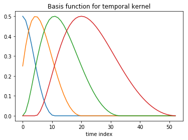

```python
time_axis, bases = utils.create_raised_cosines(nb, (0, 20), 10, binsize)
features = floatx(utils.apply_basis_function(stimulus, bases))

plt.plot(time_axis, bases)
plt.xlabel('time index')
plt.title('Basis function for temporal kernel')
```

Note that $\mathbf{S}$ is now a 4-dimensional tensor of size (nt, nb, ny, nx).

```python
print(features.shape)
```

```
(500, 4, 50, 50)
```

```python
from maprf import distributions as dist

# create the temporal kernel
with model:
    kt = addparam('kt', vector(nb), prior=dist.MvNormalIdentity(nb))

# add a stage to the model filter
with model.filter:
    rft = filters.FeatureFilter(kt, nb)
```

### Space RF

The space component $\mathbf{k}_s$ is modelled using a parametric kernel, such that $[\mathbf{k}_s]_{ij} = f(x_i, y_j)$, where:

$$\begin{equation} f(x, y) = \frac{1 + \alpha}{2}\frac{1}{\pi\sigma_{\mathrm{pos}}^2}\exp\bigg(-\frac{x^2 + y^2}{2\sigma_{\mathrm{pos}}^2}\bigg) - \frac{1 - \alpha}{2}\frac{1}{2\pi\sigma_{\mathrm{neg}}^2}\exp\bigg(-\frac{x^2 + y^2}{2\sigma_{\mathrm{neg}}^2}\bigg) \end{equation},$$

where $\sigma_{\mathrm{pos}}$ and $\sigma_{\mathrm{neg}}$ control the size of the positive and of the negative region of the receptive-field, and $\alpha \in [-1, 1]$ weights the contribution of the positive and of the negative regions.

We will assume uniform priors $\mathrm{U}(1, \sigma_{\mathrm{max}})$ for the scale parameters $\sigma_{\mathrm{pos}}$ and $\sigma_{\mathrm{neg}}$ and a uniform prior $\mathrm{U}(-1, 1)$ for $\alpha$.

As MCMC works best with unbounded variables, we will work with variables in a transformed space:

1. $\alpha = \tanh(\alpha')$: $\alpha \sim \mathrm{Uniform}(-1, 1) \rightarrow \alpha' \sim \mathrm{Logistic}(0, \frac{1}{2})$
2. $\sigma_x = 1 + (\sigma_{\mathrm{max}} - 1) \frac{1}{1 + \exp(-\sigma_x')}$: $\sigma_x' \sim \mathrm{Logistic}(0, 1)$

```python
from maprf import shapes
from maprf import transform

SIGMA_MAX = kx // 3

# create a kernel and add its parameters to the model
with model:
    _shape = addparam('shape', scalar(), prior=dist.Logistic(0., .5))
    _w_pos = addparam('w_pos', scalar(), prior=dist.Logistic(0., 1.))
    _w_neg = addparam('w_neg', scalar(), prior=dist.Logistic(0., 1.))

    ks = shapes.CenterSurround(
        shape=transform.arctanh.inverse(_shape),
        w_pos=transform.Interval(1., SIGMA_MAX).inverse(_w_pos),
        w_neg=transform.Interval(1., SIGMA_MAX).inverse(_w_neg))

    # add two parameters for the rf position
    xo = addparam('xo', scalar(int))
    yo = addparam('yo', scalar(int))

# add a stage to the model filter
with model.filter:
    rfs = filters.SpatialFilter(ks[grid])
```

### Defining the rate model

As we saw, the receptive field consists of a temporal and a spatial linear component. We must then ensure that the output of the linear stage is rectified in order to represent a proper firing rate. The output of the linear stage is rectified by a static non-linearity, in this case we will use $\exp$. Before going throught the non-linearity, we will rescale and shift the output of the linear stage in order to accomodate the baseline firing rate and the coupling strenght between stimulus and firing rate of the neuron.

We have the following model for the static non-linearity (assuming that $z_t$ is the output of the linear stage at time $t$):

$$ r_t = \exp(a + \mathbf{b}^{\top} \mathbf{z}_t) $$

In this particular case, $\mathbf{z}_t$ is a scalar variable, and it's amplitude was already shaped by the temporal component of the receptive field. Therefore, we set $\mathbf{b} = [1]$.

```python
with model:
    a = addparam('bias', scalar())

    @model.as_method
    def nonlin(x):
        return tt.exp(a + 1.0 * x)
```

## Sampling

To make sampling efficient, we group the model parameters in two categories: the receptive field position $\mathbf{x} = \{x_o, y_o\}$ and the parameters controlling the receptive-field appearance $\boldsymbol{\theta}$.

We want to sample from the posterior distyribution $p(\mathbf{x}, \boldsymbol{\theta}|\mathcal{D})$, which is proportional to the joint distribution of data $\mathcal{D}$ and parameters $p(\mathcal{D}, \mathbf{x}, \boldsymbol{\theta}) = p(\mathcal{D} | \mathbf{x}, \boldsymbol{\theta})p(\mathbf{x})p(\boldsymbol{\theta})$. The posterior can be rewritten as $p(\mathbf{x}, \boldsymbol{\theta}|\mathcal{D}) = p(\mathbf{x}| \boldsymbol{\theta},\mathcal{D}) p(\boldsymbol{\theta}|\mathcal{D})$, where $p(\boldsymbol{\theta}|\mathcal{D})$ is the posterior distribution of the receptive-field appearance independently of the receptive-field position.

$p(\boldsymbol{\theta}|\mathcal{D}) \propto p(\boldsymbol{\theta}, \mathcal{D})$ which, for discrete $\mathbf{x}$, is

$$ p(\boldsymbol{\theta}, \mathcal{D}) = \sum_i p(\mathcal{D}, \mathbf{x}_i, \boldsymbol{\theta}) = \sum_i p(\mathcal{D} | \mathbf{x}_i, \boldsymbol{\theta})p(\mathbf{x}_i)p(\boldsymbol{\theta}) = p(\boldsymbol{\theta}) \bigg(\sum_i p(\mathcal{D} | \mathbf{x}_i, \boldsymbol{\theta})p(\mathbf{x}_i)\bigg) $$

The conditional probability $p(\mathbf{x}| \boldsymbol{\theta},\mathcal{D})$ can be written as:

$$ p(\mathbf{x}| \boldsymbol{\theta},\mathcal{D}) = \frac{p(\mathcal{D} | \mathbf{x}, \boldsymbol{\theta})p(\mathbf{x})p(\boldsymbol{\theta})}{p(\boldsymbol{\theta}, \mathcal{D})} = \frac{p(\mathcal{D} | \mathbf{x}, \boldsymbol{\theta})}{\sum_i p(\mathcal{D} | \mathbf{x}_i, \boldsymbol{\theta})p(\mathbf{x}_i)} $$

At this point, we have a simple procedure to sample a pair $\big(\mathbf{x}^{(k)}, \boldsymbol{\theta}^{(k)}\big)$ from their posterior distribution w.r.t. the data:

1. sample $\boldsymbol{\theta}^{(k)} \sim p(\boldsymbol{\theta} | \mathcal{D})$
2. sample $\mathbf{x}^{(k)} \sim p(\mathbf{x}| \boldsymbol{\theta}^{(k)},\mathcal{D})$
3. repeat from 1. until enough samples have been collected

```python
import maprf.sampling
from maprf.sampler import *
```

```python
with model.define_sampler():
    s = theano.shared(features, 'X')
    r = theano.shared(response, 'Y')

    log_pr = model.log_pr()
    loglik = model.loglik([s, r])
    # posterior over parameters, marginalized (xo, yo)
    target1 = utils.logsumexp(loglik) + log_pr
    # conditional probability of (xo, yo) given the other parameters
    target2 = loglik - utils.logsumexp(loglik)

    # define the steps of the sampler
    step1 = addstep('hmc', target1, [_shape, _w_pos, _w_neg, a], stepsize=1e-3)
    step2 = addstep('pos', target2, [xo, yo])
    model.sampler.setup()
```

```python
# inspect the model parameters
model.params
```

```
[kt: [0. 0. 0. 0.],
 shape: 0.8219221234321594,
 w_pos: -0.1219354048371315,
 w_neg: 0.3293623924255371,
 xo: 26,
 yo: 34,
 bias: 2.3154046535491943]
```

To facilitate HMC in its exploration of the exploration of the parameter space, we inform the sampler about the global curvature of the target posterior distribution around its maximum. We could also use local curvature information, but a proper implementation ensuring detailed balance would come with so much computational overhead that it would overweight the benefits of such an approach.

```python
# compile the cost function of the model (its collapsed negative log-posterior)
# including gradients with respect to the model parameters
wrt = [_shape, _w_pos, _w_neg, a, kt]
cost = theano.function(wrt, [-target1, *tt.grad(-target1, wrt)], allow_input_downcast=True)
```

```python
from scipy import optimize
```

```python
# we cannot directly use the above compiled theano function with optimize.minimize
# we need to wrap it inside an adapter with the correct interface:
# this function takes a vector input and returns the associated scalar cost and a vector gradient
def cost2(vec):
    output = cost(vec[0], vec[1], vec[2], vec[3], vec[4:])
    grad = np.zeros(8)
    grad[0] = output[1]
    grad[1] = output[2]
    grad[2] = output[3]
    grad[3] = output[4]
    grad[4:] = output[5]
    return output[0], grad
```

```python
# at this point we can minimize the negative log-posterior
results = optimize.minimize(cost2, p0, jac=True)
```

```python
# inspect the optimization results
results
```

```
      fun: 18148.4706422888
 hess_inv: array([[ 2.37688543e-01,  1.42699238e-01, -1.44560223e-01,
        -4.00153153e-04,  7.61701769e-02, -4.25384941e-02,
        -4.34870317e-02, -6.73100253e-02],
       [ 1.42699238e-01,  1.36875406e+00,  3.68600914e-01,
        -5.44088514e-04,  1.26145281e-01,  1.19198463e-01,
         9.37966412e-02,  6.40725440e-02],
       [-1.44560223e-01,  3.68600914e-01,  1.71949023e+00,
         1.08335538e-04, -2.22266701e-01, -1.53249629e-01,
        -3.11077326e-02,  2.29882054e-02],
       [-4.00153153e-04, -5.44088514e-04,  1.08335538e-04,
         6.52166649e-05, -6.48452406e-04, -1.10282961e-04,
         3.26092291e-05,  3.12869938e-04],
       [ 7.61701769e-02,  1.26145281e-01, -2.22266701e-01,
        -6.48452406e-04,  7.43091694e-01, -1.41906799e-01,
        -4.17841086e-02, -6.20216352e-03],
       [-4.25384941e-02,  1.19198463e-01, -1.53249629e-01,
        -1.10282961e-04, -1.41906799e-01,  7.97833438e-01,
        -8.12198010e-02, -6.06768899e-02],
       [-4.34870317e-02,  9.37966412e-02, -3.11077326e-02,
         3.26092291e-05, -4.17841086e-02, -8.12198010e-02,
         7.80391120e-01, -2.76316014e-01],
       [-6.73100253e-02,  6.40725440e-02,  2.29882054e-02,
         3.12869938e-04, -6.20216352e-03, -6.06768899e-02,
        -2.76316014e-01,  6.31059227e-01]])
      jac: array([ 1.04514424e-04, -2.52127647e-05,  2.08616257e-05,  2.13592127e-03,
        2.35438347e-06,  2.96533108e-05,  8.71643424e-05,  1.12529844e-04])
  message: 'Desired error not necessarily achieved due to precision loss.'
     nfev: 91
      nit: 16
     njev: 79
   status: 2
  success: False
        x: array([ 0.13978309,  0.04009879, -0.03795722,  2.31040976,  0.16053044,
        0.08954011,  0.06603571,  0.05227884])
```

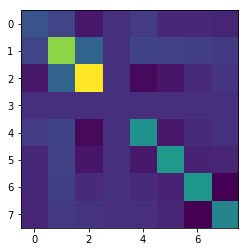

```python
# the output structure contains the (inverse) Hessian information
plt.imshow(results.hess_inv)
```

```python
# use the inverse of diagonal entries to tune the mass of the HMC sampler
hess_inv = np.float32(np.diag(results.hess_inv))
step1.set_mass(_shape, np.float32(1 / hess_inv[0]))
step1.set_mass(_w_pos, np.float32(1 / hess_inv[1]))
step1.set_mass(_w_neg, np.float32(1 / hess_inv[2]))
step1.set_mass(a, np.float32(1 / hess_inv[3]))
```

At this point, the sampler is properly initialized and we can start drawing samples.

```python
step1.stepsize = 2e-1
step1.reset()
with model:
    samples = sample(1000)
```

## Plot results

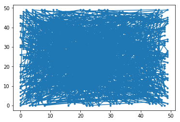

```python
import seaborn as sns
plt.plot(samples['xo'], samples['yo'], '.-')
```

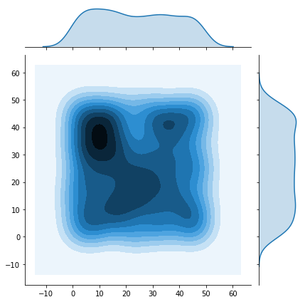

```python
ax = sns.jointplot(samples['xo'], samples['yo'], kind='kde')
```

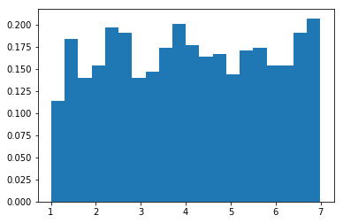

```python
plt.hist(1 + (SIGMA_MAX - 1) / (1 + np.exp(-np.stack(samples['w_neg']))), 20, density=True);
```

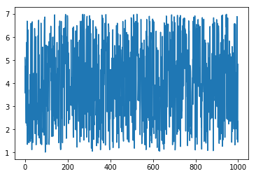

```python
plt.plot(1 + (SIGMA_MAX - 1) / (1 + np.exp(-np.stack(samples['w_neg']))))
```

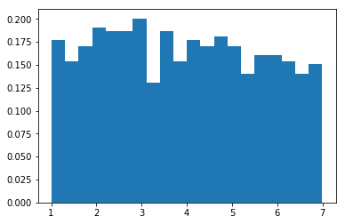

```python
plt.hist(1 + (SIGMA_MAX - 1) / (1 + np.exp(-np.stack(samples['w_pos']))), 20, density=True);
```

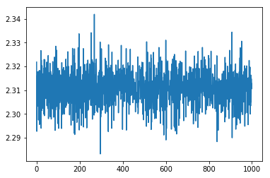

```python
plt.plot(samples['bias'])
```

```python
# inspect the acceptance rate of HMC
step1.accept
```

```
993
```

```python
# inspect the rejection rate of HMC
step1.reject
```

```
7
```